# week 6 lab

J.F.P. (Richard) Scholtens s2956586

Generation date: jun 01, 2018 - 12:36:15

# 1 Load data

```r
mydf = read.csv("lab6_temperature.csv")
str(mydf)
```

```
## 'data.frame':    1680 obs. of  8 variables:
##  $ X          : int  1 2 3 4 5 6 7 8 9 10 ...
##  $ City       : Factor w/ 56 levels "Albany, NY       ",..: 35 35 35 35 35 35 35 35 35 35 ...
##  $ Year       : int  1931 1932 1933 1934 1935 1936 1937 1938 1939 1940 ...
##  $ Latitude   : num  31.2 31.2 31.2 31.2 31.2 31.2 31.2 31.2 31.2 31.2 ...
##  $ Longitude  : num  88.5 88.5 88.5 88.5 88.5 88.5 88.5 88.5 88.5 88.5 ...
##  $ Coastal    : int  1 1 1 1 1 1 1 1 1 1 ...
##  $ Elevation  : int  218 218 218 218 218 218 218 218 218 218 ...
##  $ Temperature: num  34.7 47.8 45.3 31.2 37.2 ...
```

# 2 Make Coastal a factor

```r
str(mydf$Coastal <- as.factor(mydf$Coastal))
```

```
##  Factor w/ 2 levels "0","1": 2 2 2 2 2 2 2 2 2 2 ...
```

# 3 Centre variables

```r
mydf$center.Latitude <- mydf$Latitude - mean(mydf$Latitude)

mydf$center.Longitude <- mydf$Longitude - mean(mydf$Longitude)

mydf$center.Elevation <- mydf$Elevation - mean(mydf$Elevation)

mydf$scale.Elevation <- mydf$center.Elevation/1000
```

# 4 Boxplots

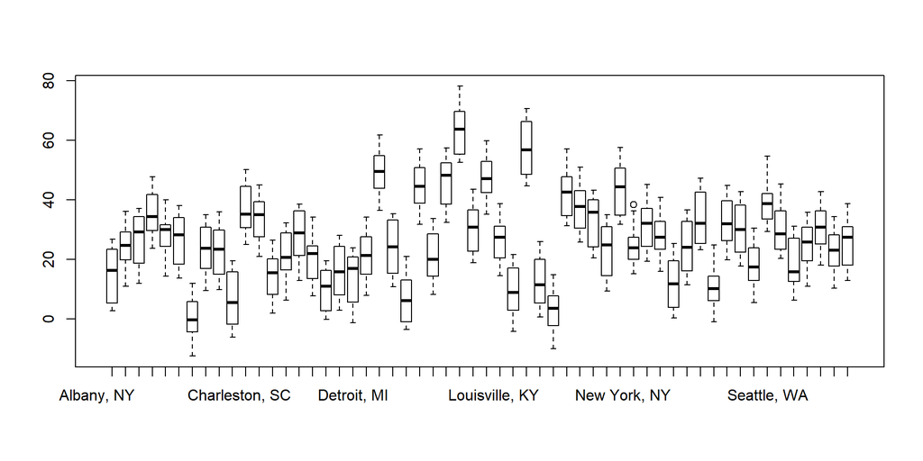

```r
boxplot(mydf$Temperature ~ mydf$City)
```

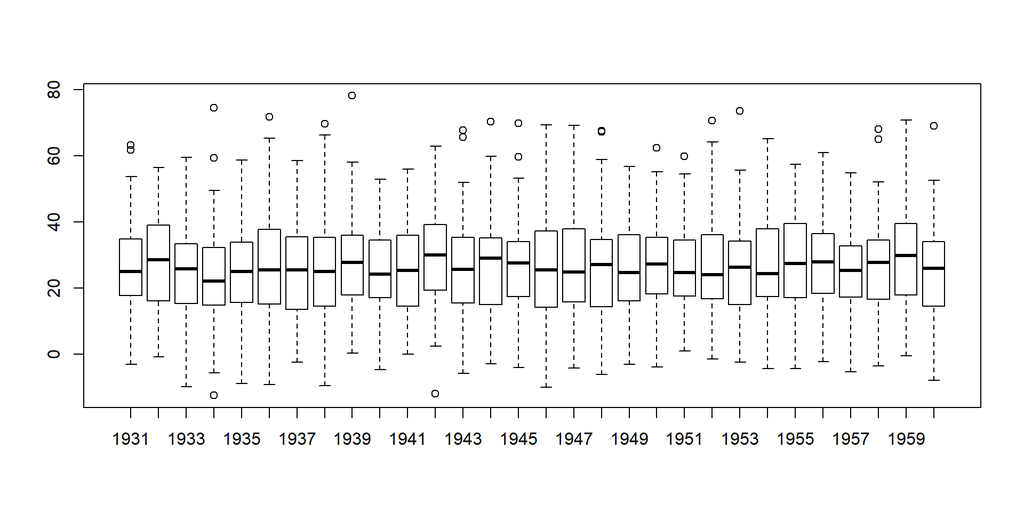

```r
boxplot(mydf$Temperature ~ mydf$Year)
```

# 5 LMER

```r
library(lme4)
m.lmer3 <- lmer(Temperature ~ Coastal + center.Latitude + center.Longitude + scale.Elevation + (1|City) + (1|Year), data=mydf, REML=F)
summary(m.lmer3)
```

```
## Linear mixed model fit by maximum likelihood  ['lmerMod']
## Formula: Temperature ~ Coastal + center.Latitude + center.Longitude +
##     scale.Elevation + (1 | City) + (1 | Year)
##    Data: mydf
##
##      AIC      BIC   logLik deviance df.resid
##  11767.8  11811.2  -5875.9  11751.8     1672
##
## Scaled residuals:
##      Min       1Q   Median       3Q      Max
## -2.10485 -0.84143  0.01266  0.81998  2.18043
##
## Random effects:
##  Groups   Name        Variance Std.Dev.
##  City     (Intercept) 15.168   3.8946
##  Year     (Intercept)  0.425   0.6519
##  Residual             59.103   7.6878
## Number of obs: 1680, groups:  City, 56; Year, 30
##
## Fixed effects:
##                  Estimate Std. Error t value
## (Intercept)       22.9139     0.9178  24.967
## Coastal1           6.4729     1.3052   4.959
## center.Latitude   -1.8955     0.1099 -17.246
## center.Longitude   0.2822     0.0431   6.548
## scale.Elevation   -2.1882     0.4656  -4.700
##
## Correlation of Fixed Effects:
##             (Intr) Costl1 cntr.Lt cntr.Ln
## Coastal1    -0.787
## center.Lttd -0.205  0.261
## centr.Lngtd -0.032  0.041 -0.040
## scale.Elvtn -0.293  0.373 -0.038  -0.433
```

All the t values are above 2. The minus numbers get an absolute value wich is higher than 2. Therefor all the predictors are significant.

This means the following:

Whenever a city is a coastal city the temperature is about 6.4729 higher.

For every unit of latitude the temperature will drop with -1.8955 degrees.

For every unit of elevation the temperature will drop with -2.1882 degrees.

# 6 Add interactions

```r
m.lmer4 <- lmer(Temperature ~ Coastal*center.Longitude + Coastal*center.Latitude + Coastal*scale.Elevation + center.Latitude*center.Elevation + center.Longitude*center.Elevation + (1|City) + (1|Year), data=mydf, REML=F)
```

```
## fixed-effect model matrix is rank deficient so dropping 1 column / coefficient
```

```r
summary(m.lmer4)$coef
```

```
##                                        Estimate   Std. Error       t value
## (Intercept)                        2.281678e+01 0.9514168148  2.398190e+01
## Coastal1                           3.508358e+00 1.2459158855  2.815887e+00
## center.Longitude                  -5.522431e-05 0.0943319067 -5.854255e-04
## center.Latitude                   -2.397192e+00 0.2108695617 -1.136813e+01
## scale.Elevation                   -3.737111e+00 1.1355677643 -3.290962e+00
## Coastal1:center.Longitude          4.629595e-01 0.1115838218  4.148984e+00
## Coastal1:center.Latitude           5.984865e-01 0.2742326851  2.182404e+00
## Coastal1:scale.Elevation          -2.431994e+00 1.0246693535 -2.373442e+00
## center.Latitude:center.Elevation   1.186935e-04 0.0001121727  1.058132e+00
## center.Longitude:center.Elevation  1.946756e-04 0.0000709043  2.745611e+00
```

```r
AIC(m.lmer4) - AIC(m.lmer3)
```

```
## [1] -11.85034
```

```r
anova(m.lmer3, m.lmer4)
```

```
## Data: mydf
## Models:
## m.lmer3: Temperature ~ Coastal + center.Latitude + center.Longitude +
## m.lmer3:     scale.Elevation + (1 | City) + (1 | Year)
## m.lmer4: Temperature ~ Coastal * center.Longitude + Coastal * center.Latitude +
## m.lmer4:     Coastal * scale.Elevation + center.Latitude * center.Elevation +
## m.lmer4:     center.Longitude * center.Elevation + (1 | City) + (1 | Year)
##         Df   AIC   BIC  logLik deviance Chisq Chi Df Pr(>Chisq)
## m.lmer3  8 11768 11811 -5875.9    11752
## m.lmer4 13 11756 11826 -5865.0    11730 21.85      5   0.000559 ***
## ---
## Signif. codes:  0 '***' 0.001 '**' 0.01 '*' 0.05 '.' 0.1 ' ' 1
```

We can see a minus integer when we check the AIC. This means the model with the interactions is better. Also the p-level of the anova test is below significance level of 0.05.

There is one interaction which is not significant. The interaction of latitude and elevation has an absolute t-value which is below 2.

# 7 Visualise interactions

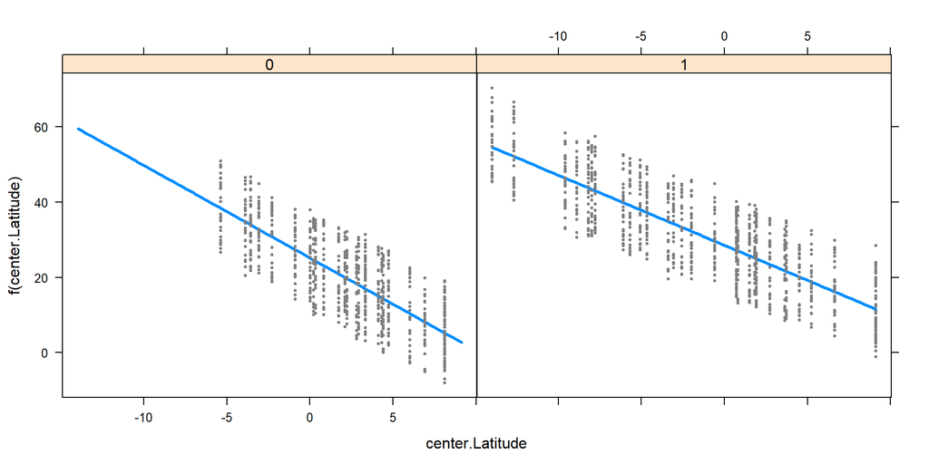

```r
library(visreg)
visreg(m.lmer4, xvar = "center.Latitude", by = "Coastal")
```

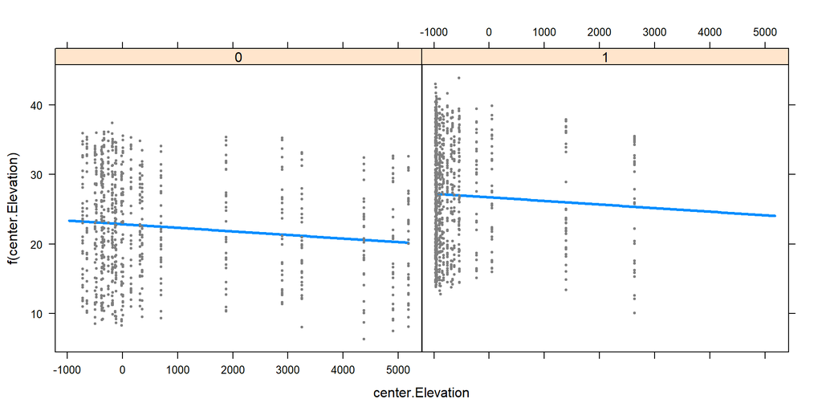

```r
visreg(m.lmer4, xvar = "center.Elevation", by = "Coastal")
```

In the first graph you can see that the temperature drops with more units of latitude for all cities.

# 8 Assumptions (normality)

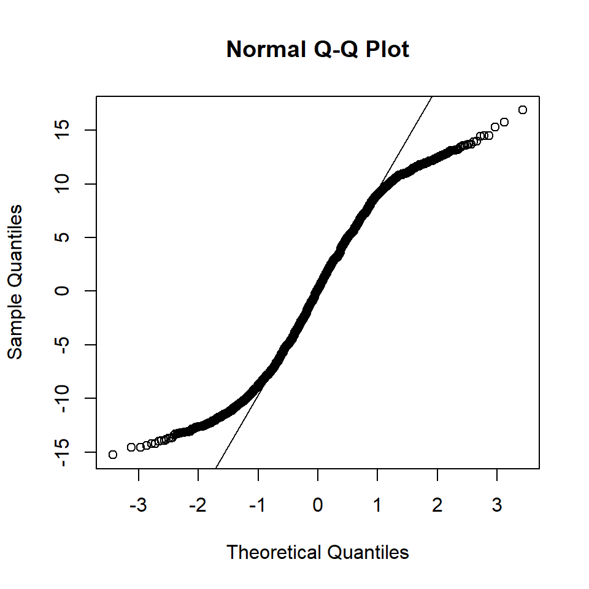

```r
qqnorm(resid(m.lmer4))
qqline(resid(m.lmer4))
```

```r
shapiro.test(resid(m.lmer4))
```

```
##
##  Shapiro-Wilk normality test
##
## data:  resid(m.lmer4)
## W = 0.96253, p-value < 2.2e-16
```

We see a slightly s-shaped line in the plot. This means it in not normally distributed. The shapiro test confirms with a p-level below the 0.05 signficance lecvel. p-level = 2.2e-16.

# 9 Assumptions (heteroscedasticity)

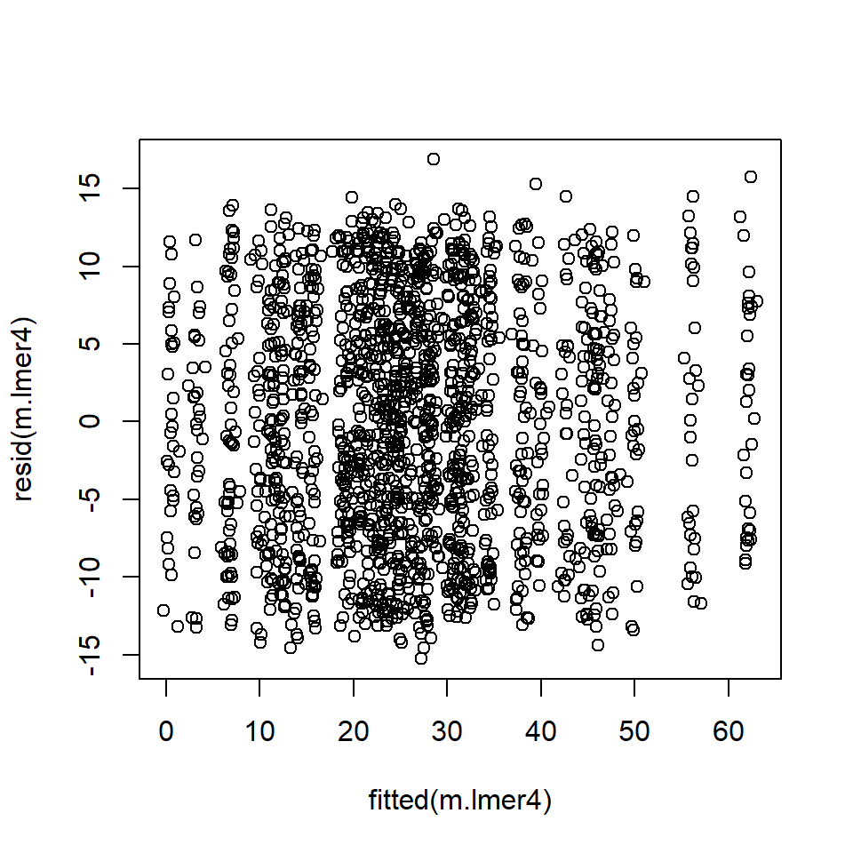

```r
plot(fitted(m.lmer4), resid(m.lmer4))
```

If look at the dots we can see that all distances on the x-axis look the same. Therefor we can state there is no heteroscedasticity.

# 10 Outliers

```r
(noutliers <- sum(abs(scale(resid(m.lmer4))) >= 2))
```

```
## [1] 4
```

```r
noutliers / nrow(mydf)
```

```
## [1] 0.002380952
```